# Analiza wydajności algorytmów

Katarzyna Fąk

19.05.2015

*Skalowanie wielowymiarowe dąży do rozmieszczenia obiektów jako punktów w przestrzeni n-wymiarowej tak, aby obiekty podobne do siebie znajdowały się bliżej.*

– Wikipedia o skalowaniu wielowymiarowym.

*Krzyżówka niepowiązanych ze sobą liczb służąca jako narzędzie do zabijania czasu dla znudzonych matematyków.*

– Nonsensopedia o macierzach.

## 1. Liczenie macierzy podobieństw

Skupiłam się na dwóch impletencjach: **dist** i **daisy** oraz dwóch funkcjach z pakietu proxy.

1. Dane ‘małe’

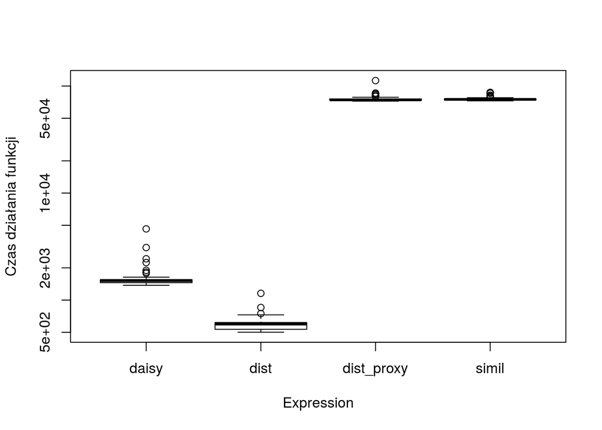

```r
library(cluster)
#install.packages("proxy")
library(proxy)
data(flower)
czasy <- microbenchmark::microbenchmark(
   daisy=daisy(flower),
   dist=stats::dist(flower),
   dist_proxy=proxy::dist(flower),
   simil=simil(flower),
   times=50L)
boxplot(czasy, ylab="Czas działania funkcji")
```

> Problemy z alokacją pamięci

Przykład ze zbiorem Allegan o wymiarach 20209x8

```r
Allegan <- read.csv("http://www.calvin.edu/~stob/data/Allegan.csv")
dim(Allegan)
```

```
## [1] 20209     8
```

```r
# daisy(Allegan)
# Error: cannot allocate vector of size 1.5 Gb
# dist(Allegan)
# Error: cannot allocate vector of size 1.5 Gb

# Podobnie funkcje z pakietu proxy.
```

> Gdzie zatem są ‘granice wytrzymalości’?

Wylosujemy (z rozkładu U(0,1)) 30 kwadratowych macierzy o rozmiarach od 10x10 co 50 w górę. Wykonamy na nich dwie z szybszych funkcji: stats:dist(), daisy() oraz jedną z funkcji z pakietu proxy. Czy któraś z nich zyskuje na wymiarze macierzy?

Skutkiem wielu prób na pamięci mojego komputera jako górną granicę wielkości macierzy przyjmę 1500.

```r
doMatrix <- function(n) matrix(runif(n^2,0,1), nrow=n)
m <- seq(from=10, to=1500, by=50)
M <- N <- list()
for(i in seq_along(m)){
   doMatrix(m[i])->M[[i]]
}
```

Oto jak obrazowo wyglądał czas wykonywania poszczególnych funkcji:

```r
library(cluster)
X_dist <- sapply(M, function(x) system.time(dist(x))[1])
X_daisy <- sapply(M, function(x) system.time(daisy(x))[1])
```

```r
X_simil <- sapply(M, function(x) system.time(simil(x))[1])
```

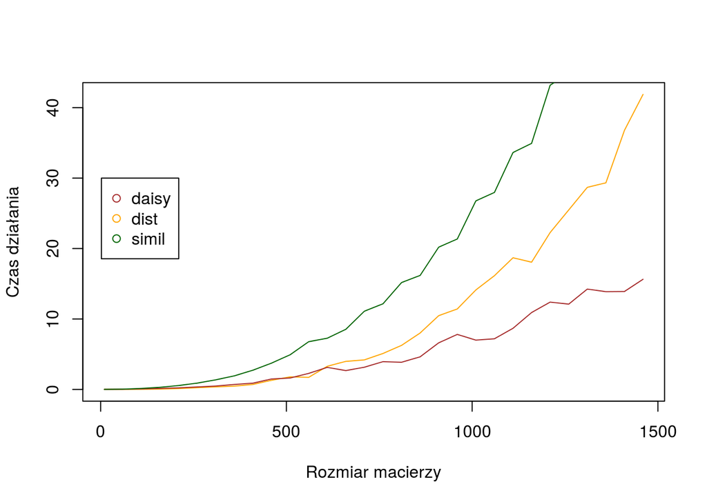

```r
plot(m, X_dist, col="orange", type="l", ylab="Czas działania", xlab="Rozmiar macierzy")
lines(m, X_daisy, col="brown")
lines(m, X_simil, col="darkgreen")
legend(2,30, c("daisy","dist","simil"), col=c("brown","orange","darkgreen"), pch=c(1,1,1))
```

Jak widać, na małej macierzy o ułamkową część sekund lepiej wypadała implementacja dist(), jednak do pracy z większymi macierzami (wymiaru 600+) wolelibyśmy używać funkcji daisy().

# 2. Wydajność algorytmów skalowania wielowymiarowego

Tu porównam ze sobą następujące funkcje: isoMDS(), cmdscale(), indscale{SensoMineR}.

## Macierz ‘mała’

```r
library(MASS)
library(SensoMineR)

A <- doMatrix(10)
Aa <- microbenchmark::microbenchmark(
   isoMDS=isoMDS(A),
   cmdscale=cmdscale(A),
   indscal=indscal(A),
   times=20)
```

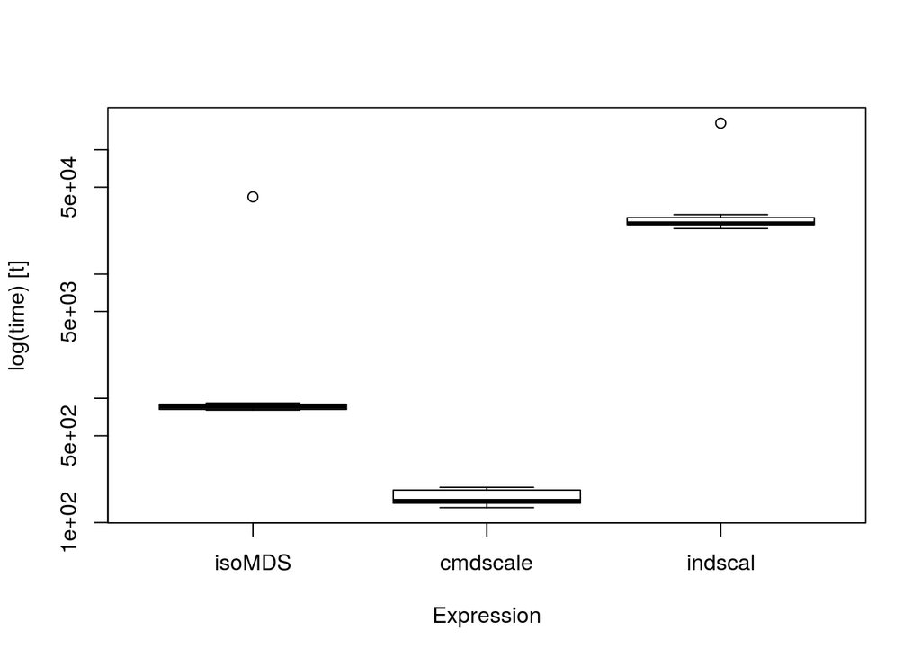

## Macierz ‘średnia’

W tych testach funkcja indscale() odpada ze względu na problem z alokacją pamięci.

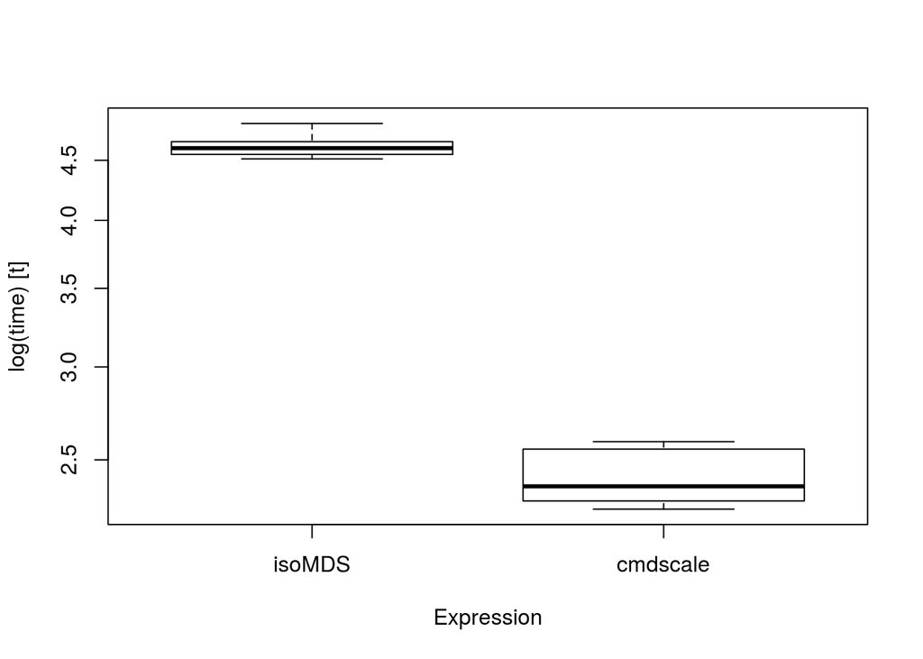

```r
B <- doMatrix(1000)
Bb <- microbenchmark::microbenchmark(
   isoMDS=isoMDS(B),
   cmdscale=cmdscale(B),
   times=10)
boxplot(Bb)
```

Wszystkie powyższe funkcje mają problemy z alokacją pamięci na macierzy 10k x 10k.

> A jak rzecz przedstawia się w kolejnych *krokach macierzowych*??

Test ponownie wykonano na 30 macierzach rozmiarów od 10 co 50 w górę. Większe macierze miały problemy z alokacją pamięci. Lista M tych macierzy przyjmuje rozmiar 166.5 Mb.

```r
X_cmdscale <- sapply(M, function(x) system.time(cmdscale(daisy(x)))[1])
X_isoMDS <- sapply(M, function(x) system.time(isoMDS(daisy(x)))[1])
```

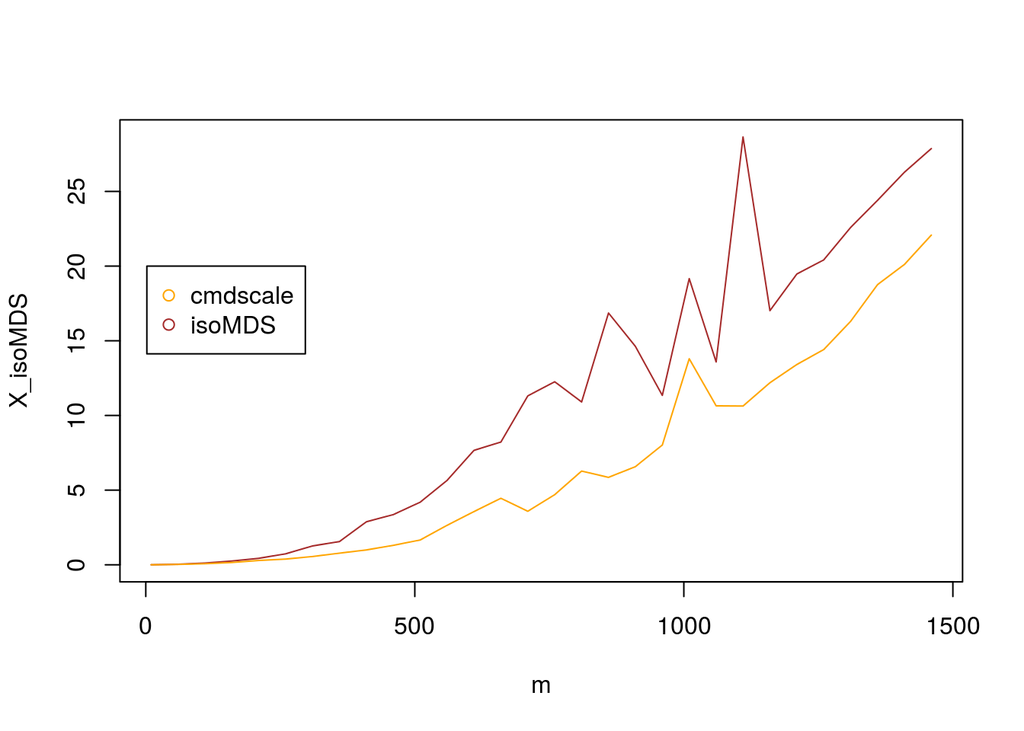

```r
plot(m, X_isoMDS, col="brown", type="l")
lines(m, X_cmdscale, col="orange", ylab='dist')
legend(2,20, c("cmdscale","isoMDS"), col=c("orange","brown"), pch=c(1,1))
```